# Introduction à Python

## Intérêt de Python

Langage de programmation en pleine croissance dans le domaine de la **Data Science** et du **Big Data**

- Utilisation en mode console : Langage scripté (comme R, bash, SQL...)
  - Exécution des commandes les unes après les autres
- 2 utilisations classiques
  - Ecriture d'un script dans un fichier texte (souvent avec l'extension `.py`)
  - Utilisation du mode *notebook*
    - Module `jupyter` à installer
    - Documents contenant à la fois le code, les résultat et du texte

## Eléments de base

- Types de données classiques
  - Entier, réel, chaîne de caractères, booléen
  - Liste `[]` et tuple `()` (liste constante) : éléments pas forcément du même type
  - Dictionnaire `{}` : ensemble de couples *clé-valeur*
- Opérateurs usuels :
  - Arithmétiques : `+`, `-`, `*`, `/`, `//`, `%`, `**
  - Comparaisons : `>`, `>=`, `<`, `<=`, `==`, `!=`
  - Booléens : `|`, `&`, `not()`
- Variables
  - Pas de mot-clé pour la définition d'une variable : définie/créée lors de sa première affectation
  - **Type dynamique** (dépend uniquement de la valeur de son affectation)

### Chaînes de caractères

- Chaîne de caractère : quotes simples (`''`) ou doubles (`""`)
  - Par défaut, simples quotes
  - En présence d'une apostrophe dans la chaîne, déclarer avec des doubles quotes
- Longueur de la chaîne avec la fonction `len()`

```python
a = 'bonjour'
print(a)

len(a)
```

```
bonjour
```

```
7
```

```python
a = 'bonjour'
a[1:5]
```

```
'onjo'
```

```python
a[0:3]
```

```
'bon'
```

```python
a[:3]
```

```
'bon'
```

```python
a[3:len(a)]
```

```
'jour'
```

```python
a[3:]
```

```
'jour'
```

```python
a[::]
```

```
'bonjour'
```

```python
a[::-1]
```

```
'ruojnob'
```

```python
a[::2]
```

```
'bnor'
```

```python
a[1:5:2]
```

```
'oj'
```

```python
a[5:1:-2]
```

```
'uj'
```

#### Fonctions sur les chaînes

- Changement de casse : `upper()` ou `lower()`
- Mise en majuscule des premières lettres de chaque mot : `capitalize()`
- Recherche d'une sous-chaîne : `find()` - première occurence
- Remplacement d'une sous-chaîne : `replace()`
- Dénombrement de sous-chaînes : `count()`
- Découpage en sous-chaînes selon un caractère : `split()`

```python
a = 'bonjour'
a.upper()
```

```
'BONJOUR'
```

```python
a.capitalize()
```

```
'Bonjour'
```

```python
a.find('j')
```

```
3
```

```python
a.replace('jour', 'soir')
```

```
'bonsoir'
```

```python
a.count('o')
```

```
2
```

```python
a.split('j')
```

```
['bon', 'our']
```

### Tuples

- Ensemble déclaré via des `()`
  - Composé de valeurs pas forcément de même type et éventuellement complexe (*i.e.* tuples, listes ou dictionnaires)
  - **Non modifiable** : constante.

```python
a = (3, 1, 9, 7)
print(a)
a[0]
```

```
(3, 1, 9, 7)
```

```
3
```

- Possible d'utiliser les mêmes outils d'indexation en séquence vu pour les chaîne

### Listes

- Ensemble déclarée via des `[]`
  - Composé d'éléments pas forcément tous du même type et possiblement complexe (*i.e.* tuples, listes ou dictionnaires)
  - A la différence d'un tuple, une liste est modifiable

```python
a = [3, 1, 9, 7]
print(a)
len(a)
```

```
[3, 1, 9, 7]
```

```
4
```

```python
a[0]
```

```
3
```

```python
a[1:3]
```

```
[1, 9]
```

- Possible d'utiliser les mêmes outils d'indexation en séquence vu pour les chaînes

#### Fonctions sur les listes

- **Toutes ces fonctions modifient directement la liste**
- Inverser la liste : `reverse()`
- Tri de la liste : `sort()` (avec option `reverse=True` pour tri décroissant)
- Récupérer (et supprimer de la liste) le dernier élément : `pop()`
- Ajouter un élément à la fin : `append()`
- Insérer un élément dans la liste : `insert()` (position + valeur)
- Supprimer des valeurs passées: `remove()` (celles passées en paramètres)

> Il est nécessaire **d'afficher** la liste `a` pour voir le résultat de la fonction

```python
a = [3, 1, 9, 7]
a.reverse()
a
```

```
[7, 9, 1, 3]
```

```python
a.sort()
a
```

```
[1, 3, 7, 9]
```

```python
a.sort(reverse=True)
a
```

```
[9, 7, 3, 1]
```

```python
a.pop()
```

```
1
```

```python
a
```

```
[9, 7, 3]
```

```python
a.append(5)
a
```

```
[9, 7, 3, 5]
```

```python
a.insert(0, 6)
a
```

```
[6, 9, 7, 3, 5]
```

```python
a.remove(7)
a
```

```
[6, 9, 3, 5]
```

#### Opérateurs sur les listes

- Concaténation de deux listes : `+`
- Répétition d'une liste : `*`

```python
a = [3, 1, 9, 7]
b = [1, 2]
a + b
```

```
[3, 1, 9, 7, 1, 2]
```

```python
a * 2
```

```
[3, 1, 9, 7, 3, 1, 9, 7]
```

#### *List comprehension*

- Mécanisme spécifique: *list comprehension* (fonctionnant aussi sur les chaînes et les tuples)
  - Récupérer les valeurs (ou un calcul sur chaque valeur) pour tous les éléments de la liste (ou certains si on applique un `if`)

```python
a = [3, 1, 9, 7]
[x**2 for x in a]
```

```
[9, 1, 81, 49]
```

```python
[x**2 for x in a if x >= 4]
```

```
[81, 49]
```

```python
[x**2 if x >= 4 else -x for x in a]
```

```
[-3, -1, 81, 49]
```

#### Passage de référence

**Attention** : passage de référence lorsqu'on copie une liste

- Si modification d'une, alors modification de l'autre

```python
a = [1, 2, 3, 4]
b = a
a[0] = 5
b[1] = 9
print(a, b)
```

```
[5, 9, 3, 4] [5, 9, 3, 4]
```

- Duppliquer la liste : `copy()`

```python
a = [1, 2, 3, 4]
b = a.copy()
a[0] = 5
b[1] = 9
print(a, b)
```

```
[5, 2, 3, 4] [1, 9, 3, 4]
```

### Dictionnaires

- `dict` : listes nommées définies via des `{}`
  - ensemble de couples clé/valeur (ou champs/valeur)
  - éléments pas forcément tous du même type, et potentiellement complexe (*i.e* tuples, listes ou dictionnaires)

```python
a = {
    "nom": "Jollois",
    "prenom": "FX",
    "langues": ["R", "Python", "SQL", "SAS"],
    "labo": { "nom": "LIPADE", "lieu": "CUSP"}
}
print(a)
len(a)
```

```
{'nom': 'Jollois', 'prenom': 'FX', 'langues': ['R', 'Python', 'SQL', 'SAS'], 'labo': {'nom': 'LIPADE', 'lieu': 'CUSP'}}
```

```
4
```

#### Accès aux éléments

- Utilisation de la clé pour accéder à la valeur

```python
a = {
    "nom": "Jollois",
    "prenom": "FX",
    "langues": ["R", "Python", "SQL", "SAS"],
    "labo": { "nom": "LIPADE", "lieu": "CUSP"}
}
a["nom"]
```

```
'Jollois'
```

```python
a["langues"]
```

```
['R', 'Python', 'SQL', 'SAS']
```

```python
a["langues"][0]
```

```
'R'
```

```python
a["labo"]
```

```
{'nom': 'LIPADE', 'lieu': 'CUSP'}
```

```python
a["labo"]["lieu"]
```

```
'CUSP'
```

#### Fonctions sur les dictionnaires

- Récupérer la valeur d'une clé : `get()`
- Liste des clés : `keys()`
- Valeurs dans le même ordre que `keys()`: `values()`
- Récupérer le dernier item (en le supprimer du dictionnaire) : `popitem()`
- Récupérer un item (en le supprimant du dictionnaire aussi) : `pop()`

> Afficher le dictionnaire `a` pour voir le résultat des deux dernières fonctions aussi

```python
a = {
    "nom": "Jollois",
    "prenom": "FX",
    "langues": ["R", "Python", "SQL", "SAS"],
    "labo": { "nom": "LIPADE", "lieu": "CUSP"}
}
a["type"] = "MCF"
a.get("nom")
```

```
'Jollois'
```

```python
a.keys()
```

```
dict_keys(['nom', 'prenom', 'langues', 'labo', 'type'])
```

```python
a.values()
```

```
dict_values(['Jollois', 'FX', ['R', 'Python', 'SQL', 'SAS'], {'nom': 'LIPADE', 'lieu': 'CUSP'}, 'MCF'])
```

```python
a.popitem()
```

```
('type', 'MCF')
```

```python
a
```

```
{'nom': 'Jollois',
 'prenom': 'FX',
 'langues': ['R', 'Python', 'SQL', 'SAS'],
 'labo': {'nom': 'LIPADE', 'lieu': 'CUSP'}}
```

```python
a.pop("nom")
```

```
'Jollois'
```

```python
a
```

```
{'prenom': 'FX',
 'langues': ['R', 'Python', 'SQL', 'SAS'],
 'labo': {'nom': 'LIPADE', 'lieu': 'CUSP'}}
```

#### Passage de référence

- Idem que pour les listes, **attention**

```python
a = { "nom": "Jollois", "prenom": "FX" }
b = a
b["prenom"] = "Xavier"
print(a, b)
print(a)
```

```
{'nom': 'Jollois', 'prenom': 'Xavier'} {'nom': 'Jollois', 'prenom': 'Xavier'}
{'nom': 'Jollois', 'prenom': 'Xavier'}
```

- Fonction `copy()` : copie indépendante de l'objet initial

```python
a = { "nom": "Jollois", "prenom": "FX" }
b = a.copy()
b["prenom"] = "Xavier"
print(a, b)
```

```
{'nom': 'Jollois', 'prenom': 'FX'} {'nom': 'Jollois', 'prenom': 'Xavier'}
```

#### *dict comprehension*

- Identique au mécanisme de *list comprehension* (avec `if` et `else` si besoin)
- Dans ce cas, utiliser deux variables : clé et sa valeur

```python
fruits = ["pommes", "bananes", "poires", "oranges"]
nombres = [5, 2, 10, 4]
{fruits[i]:nombres[i] for i in range(4)}
```

```
{'pommes': 5, 'bananes': 2, 'poires': 10, 'oranges': 4}
```

- Fonction `dict()` appliquée sur le résultat de `zip()` des deux listes : même résultat.

```python
fruits = ["pommes", "bananes", "poires", "oranges"]
nombres = [5, 2, 10, 4]
dict(zip(fruits, nombres))
```

```
{'pommes': 5, 'bananes': 2, 'poires': 10, 'oranges': 4}
```

### Traitement conditionnel - `if`

- Avec `if`, `else` et `elif`
- Indentation pour indiquer que les expressions sont dans le bloc
- Pas de `switch` ou `case`

```python
a = 3
if (a > 2):
    print("sup")
```

```
sup
```

```python
if (a > 2):
    print("dans le IF")
    print("sup")
```

```
dans le IF
sup
```

```python
if (a > 2):
    print("sup")
elif (a > 0):
    print("mid")
else:
    print("inf")
```

```
sup
```

### Traitement itératif - `for`

- Boucle `for`
- Fonction `range()` pour avoir les valeurs entre 0 (par défaut) et la valeur passée en paramètre -1
  - Si deux paramètres : du premier paramètre au deuxième - 1
  - Si trois paramètres : définition du pas
- `i` persistant à la boucle (garde la dernière valeur)

```python
for i in range(5):
    print(i)

print("dernière valeur de i :", i)
```

```
0
1
2
3
4
dernière valeur de i : 4
```

| Exemple de `range()` | Valeurs prises |
| --- | --- |
| range(5) | 0, 1, 2, 3, 4 |
| range(5, 10) | 5, 6, 7, 8, 9 |
| range(5, 10, 2) | 5, 7, 9 |
| range(10, 5, -1) | 10, 9, 8, 7, 6 |

- Possible d'utiliser une `list` ou un `tuple`
  - Exemple : `for i in [4, 1, 10]` → 4, 1, 10
- En utilisant une chaîne de caractère, on peut naviguer dans celle-ci
  - Exemple : `for l in "Bonjour"` → "b", "o", "n", "j", "o", "u", "r"
- Mais en utilisant un groupe de chaîne (list ou tuple), on travaille sur les chaînes au complet.
  - Exemple : `for l in ("jour", "soir")` → "jour", "soir"
- Fonction `enumerate()` permet de récupérer à la fois les indices des valeurs et les valeurs
  - Exemple : `for i, x in enumerate([3, 1, 9, 4])`
    - `i` → : 0, 1, 2, 3
    - `x` → : 3, 1, 9, 4
- Fonction `zip()` : travail sur plusieurs groupes de valeurs (ici deux listes)
  - Notez que cette fonction limite le résultat à la taille du plus petit groupe
  - Exemple : `for i, j in zip([3, 1, 9, 4], ["trois", "un", "neuf"])`
    - `i` → : 3, 1, 9
    - `j` → : "trois", "un", "neuf"
- Boucle sur un dictionnaire : prend les noms des champs
  - Exemple : `for i in { 0: "lundi", 1: "mardi", 6: "dimanche"}`
    - `i` → : 0, 1, 6

### Traitement itératif - `while`

- Boucle `while` : teste en début de boucle si une condition est toujours vérifiée
- A la fin, paramètre de test = première valeur à rendre la condition fausse
- Ici, `i += 1` raccourci pour `i = i + 1`

```python
i = 0
while i < 5:
    print(i)
    i += 1

print("Valeur de i :", i)
```

```
0
1
2
3
4
Valeur de i : 5
```

### Fonctions

- Opérateur `def` pour la définir
- Procédure = fonction ne renvoyant rien
- Opérateur `return` indiquant le résultat à renvoyer
- Bloc d'instructions défini selon l'indentation

```python
def pi():
    res = 3.141593
    return res

pi()
```

```
3.141593
```

```python
def afficheBonjour():
    print("Bonjour")

afficheBonjour()
```

```
Bonjour
```

#### Paramètres des fonctions

- Possible de passer un paramètre à une fonction (ou plusieurs)
- Pas de type à définir
- Appel de la fonction sans valeur pour un paramètre défini = une erreur

```python
def afficheBonjour(nom):
    print("Bonjour", nom)

afficheBonjour("Jollois")
```

```
Bonjour Jollois
```

- Si plusieurs paramètres, appel classique ou avec nommage des paramètres

```python
def afficheBonjour(nom, prenom):
    print("Bonjour", prenom, nom)

afficheBonjour("Jollois", "FX")
afficheBonjour(nom = "Jollois", prenom = "FX")
afficheBonjour(prenom = "FX", nom = "Jollois")
```

```
Bonjour FX Jollois
Bonjour FX Jollois
Bonjour FX Jollois
```

- Valeur par défaut pour un paramètre

```python
def afficheBonjour(nom, prenom = "?"):
    print("Bonjour", prenom, nom)

afficheBonjour("Jollois", "FX")
afficheBonjour("Jollois")
```

```
Bonjour FX Jollois
Bonjour ? Jollois
```

#### Gestion des erreurs

- Usuel de gérer les erreurs d'exécution dans une fonction
- Opérateur `try`
  - premier bloc : code à exécuter normalement
  - bloc `except`: marche à suivre en cas d'erreur lors de l'exécution du bloc `try`
  - bloc `finally` : suite d'instructions à réaliser après la gestion de l'erreur (optionnel)

```python
def somme(v):
    try:
        res = sum(v)
    except:
        print("Erreur : somme impossible !")
        res = None
    finally:
        return res

a = somme([1, 3, 5])
print(a)
a = somme(["un", 3, 5])
print(a)
```

```
9
Erreur : somme impossible !
None
```

## Utilisation de Python pour l'ingénierie de la donnée

### Modules utiles

- [`numpy`](https://numpy.org) : calcul scientifique
- [`scipy`](https://scipy.org) : extension de `numpy`
- [`matplotlib`](https://matplotlib.org) : visualisation
- [`pandas`](https://pandas.pydata.org) : manipulation de données
- [`seaborn`](https://seaborn.pydata.org) : visualisation statistique de données

> La dernière ligne permettra de voir le résultat des graphiques dans le document.

```python
import matplotlib.pyplot
import scipy.stats
import numpy
import pandas
import seaborn

%matplotlib inline
```

### Données utilisées

- Données [`tips`](https://fxjollois.github.io/donnees/tips.csv) : informations [ici](https://www.rdocumentation.org/packages/reshape2/versions/1.4.2/topics/tips)

```python
tips = pandas.read_csv("https://fxjollois.github.io/donnees/tips.csv", header = 0, sep = ",")
tips.head()
```

|  | total_bill | tip | sex | smoker | day | time | size |
| --- | --- | --- | --- | --- | --- | --- | --- |
| 0 | 16.99 | 1.01 | Female | No | Sun | Dinner | 2 |
| 1 | 10.34 | 1.66 | Male | No | Sun | Dinner | 3 |
| 2 | 21.01 | 3.50 | Male | No | Sun | Dinner | 3 |
| 3 | 23.68 | 3.31 | Male | No | Sun | Dinner | 2 |
| 4 | 24.59 | 3.61 | Female | No | Sun | Dinner | 4 |

| Fonction | Commentaire |
| --- | --- |
| `tips.head()` | Premières lignes du tableau (5 par défaut) |
| `tips.shape` | Nombre de lignes et de colonnes |
| `tips.count()` | Nombre de valeurs non nulles pour chaque colonne |
| `tips.info()` | Combinaisons de plusieurs infos |
| `tips.columns` | Noms des colonnes |
| `list(tips)` | Liste des noms de colonnes |

## Manipulation de données

Comment réaliser les opérations classiques en bases de données ?

- Restriction
- Projection
- Tri et limitation des résultats
- Ajout de nouvelles variables (via des valeurs ou un calcul à partir des autres)
- Agrégats
- Modification de la forme du tableau de données
- Jointures (qui ne seront pas vues ici)
- Autres opérations, spécifiques à Python, pas vues ici

**Note Bene** : certaines fonctions renvoient un nouvel objet qu'il faudra donc stocker dans une variable (nouvelle ou la même). Par contre, d'autres fonctions modifient directement l'objet en question.

### Restriction

- Sélectionner un certain nombre de lignes de la table, selon une condition
- Fonction `query()`
  - Paramètre : une chaîne de caractères contenant la condition à appliquer

```python
tips.query('total_bill > 48') # que les factures de plus de 48
```

|  | total_bill | tip | sex | smoker | day | time | size |
| --- | --- | --- | --- | --- | --- | --- | --- |
| 59 | 48.27 | 6.73 | Male | No | Sat | Dinner | 4 |
| 156 | 48.17 | 5.00 | Male | No | Sun | Dinner | 6 |
| 170 | 50.81 | 10.00 | Male | Yes | Sat | Dinner | 3 |
| 212 | 48.33 | 9.00 | Male | No | Sat | Dinner | 4 |

```python
tips.query('day.isin(("Sat", "Sun"))') # que les factures ayant eu lieu un samedi ou un dimanche
```

|  | total_bill | tip | sex | smoker | day | time | size |
| --- | --- | --- | --- | --- | --- | --- | --- |
| 0 | 16.99 | 1.01 | Female | No | Sun | Dinner | 2 |
| 1 | 10.34 | 1.66 | Male | No | Sun | Dinner | 3 |
| 2 | 21.01 | 3.50 | Male | No | Sun | Dinner | 3 |
| 3 | 23.68 | 3.31 | Male | No | Sun | Dinner | 2 |
| 4 | 24.59 | 3.61 | Female | No | Sun | Dinner | 4 |
| ... | ... | ... | ... | ... | ... | ... | ... |
| 238 | 35.83 | 4.67 | Female | No | Sat | Dinner | 3 |
| 239 | 29.03 | 5.92 | Male | No | Sat | Dinner | 3 |
| 240 | 27.18 | 2.00 | Female | Yes | Sat | Dinner | 2 |
| 241 | 22.67 | 2.00 | Male | Yes | Sat | Dinner | 2 |
| 242 | 17.82 | 1.75 | Male | No | Sat | Dinner | 2 |

163 rows × 7 columns

```python
tips.query('size > 4 & sex == "Male"') # que les tables de plus de 4 convives et payées par un homme
```

|  | total_bill | tip | sex | smoker | day | time | size |
| --- | --- | --- | --- | --- | --- | --- | --- |
| 141 | 34.30 | 6.7 | Male | No | Thur | Lunch | 6 |
| 142 | 41.19 | 5.0 | Male | No | Thur | Lunch | 5 |
| 156 | 48.17 | 5.0 | Male | No | Sun | Dinner | 6 |
| 185 | 20.69 | 5.0 | Male | No | Sun | Dinner | 5 |
| 187 | 30.46 | 2.0 | Male | Yes | Sun | Dinner | 5 |
| 216 | 28.15 | 3.0 | Male | Yes | Sat | Dinner | 5 |

- Possibilité de faire référence à une variable avec `@`

```python
a = 48
tips.query("total_bill > @a") # idem première ligne ci-dessus
```

|  | total_bill | tip | sex | smoker | day | time | size |
| --- | --- | --- | --- | --- | --- | --- | --- |
| 59 | 48.27 | 6.73 | Male | No | Sat | Dinner | 4 |
| 156 | 48.17 | 5.00 | Male | No | Sun | Dinner | 6 |
| 170 | 50.81 | 10.00 | Male | Yes | Sat | Dinner | 3 |
| 212 | 48.33 | 9.00 | Male | No | Sat | Dinner | 4 |

### Projection

- Sélectionner certaines colonnes de la tables
- Fonction `filter()` :
  - Paramètre `items` : liste des noms à garder
  - Paramètre `axis` : axe à regarder (colonne ou ligne - colonne par défaut pour `DataFrame`)
  - Paramètre `like` : comparaison à une chaîne
  - Paramètre `regex` : utilisation d'[expressions régulières](https://fr.wikipedia.org/wiki/Expression_régulière)

```python
tips.filter(["sex", "total_bill"]) # que sex et total_bill donc
```

|  | sex | total_bill |
| --- | --- | --- |
| 0 | Female | 16.99 |
| 1 | Male | 10.34 |
| 2 | Male | 21.01 |
| 3 | Male | 23.68 |
| 4 | Female | 24.59 |
| ... | ... | ... |
| 239 | Male | 29.03 |
| 240 | Female | 27.18 |
| 241 | Male | 22.67 |
| 242 | Male | 17.82 |
| 243 | Female | 18.78 |

244 rows × 2 columns

```python
tips.filter(like = "ti") # que les variables ayant "ti" dans leur nom
```

|  | tip | time |
| --- | --- | --- |
| 0 | 1.01 | Dinner |
| 1 | 1.66 | Dinner |
| 2 | 3.50 | Dinner |
| 3 | 3.31 | Dinner |
| 4 | 3.61 | Dinner |
| ... | ... | ... |
| 239 | 5.92 | Dinner |
| 240 | 2.00 | Dinner |
| 241 | 2.00 | Dinner |
| 242 | 1.75 | Dinner |
| 243 | 3.00 | Dinner |

244 rows × 2 columns

```python
tips.filter(regex = "t.*i")
# que les variables ayant la lettre "t" puis la lettre "i" (avec ou sans caractères entre)
```

|  | total_bill | tip | time |
| --- | --- | --- | --- |
| 0 | 16.99 | 1.01 | Dinner |
| 1 | 10.34 | 1.66 | Dinner |
| 2 | 21.01 | 3.50 | Dinner |
| 3 | 23.68 | 3.31 | Dinner |
| 4 | 24.59 | 3.61 | Dinner |
| ... | ... | ... | ... |
| 239 | 29.03 | 5.92 | Dinner |
| 240 | 27.18 | 2.00 | Dinner |
| 241 | 22.67 | 2.00 | Dinner |
| 242 | 17.82 | 1.75 | Dinner |
| 243 | 18.78 | 3.00 | Dinner |

244 rows × 3 columns

- Possibiltié de supprimer les doublons avec `drop_duplicates()`

```python
tips.filter(["sex", "smoker"]).drop_duplicates()
```

|  | sex | smoker |
| --- | --- | --- |
| 0 | Female | No |
| 1 | Male | No |
| 56 | Male | Yes |
| 67 | Female | Yes |

### Tri et limitation des résultats

- Tri : Fonction `sort_values()`
  - Paramètre : la ou les variables à utiliser
  - Tri descendant : valeur du paramètre `ascending=False` (`True` par défaut)

```python
tips.sort_values(by = "total_bill") # Tri par total croissant
```

|  | total_bill | tip | sex | smoker | day | time | size |
| --- | --- | --- | --- | --- | --- | --- | --- |
| 67 | 3.07 | 1.00 | Female | Yes | Sat | Dinner | 1 |
| 92 | 5.75 | 1.00 | Female | Yes | Fri | Dinner | 2 |
| 111 | 7.25 | 1.00 | Female | No | Sat | Dinner | 1 |
| 172 | 7.25 | 5.15 | Male | Yes | Sun | Dinner | 2 |
| 149 | 7.51 | 2.00 | Male | No | Thur | Lunch | 2 |
| ... | ... | ... | ... | ... | ... | ... | ... |
| 182 | 45.35 | 3.50 | Male | Yes | Sun | Dinner | 3 |
| 156 | 48.17 | 5.00 | Male | No | Sun | Dinner | 6 |
| 59 | 48.27 | 6.73 | Male | No | Sat | Dinner | 4 |
| 212 | 48.33 | 9.00 | Male | No | Sat | Dinner | 4 |
| 170 | 50.81 | 10.00 | Male | Yes | Sat | Dinner | 3 |

244 rows × 7 columns

```python
tips.sort_values(by = "total_bill", ascending = False) # Tri décroissant
```

|  | total_bill | tip | sex | smoker | day | time | size |
| --- | --- | --- | --- | --- | --- | --- | --- |
| 170 | 50.81 | 10.00 | Male | Yes | Sat | Dinner | 3 |
| 212 | 48.33 | 9.00 | Male | No | Sat | Dinner | 4 |
| 59 | 48.27 | 6.73 | Male | No | Sat | Dinner | 4 |
| 156 | 48.17 | 5.00 | Male | No | Sun | Dinner | 6 |
| 182 | 45.35 | 3.50 | Male | Yes | Sun | Dinner | 3 |
| ... | ... | ... | ... | ... | ... | ... | ... |
| 149 | 7.51 | 2.00 | Male | No | Thur | Lunch | 2 |
| 111 | 7.25 | 1.00 | Female | No | Sat | Dinner | 1 |
| 172 | 7.25 | 5.15 | Male | Yes | Sun | Dinner | 2 |
| 92 | 5.75 | 1.00 | Female | Yes | Fri | Dinner | 2 |
| 67 | 3.07 | 1.00 | Female | Yes | Sat | Dinner | 1 |

244 rows × 7 columns

```python
tips.sort_values(by = ["smoker", "total_bill"], ascending = [True, False]) # Tri avec smoker croissant et total décroissant
```

|  | total_bill | tip | sex | smoker | day | time | size |
| --- | --- | --- | --- | --- | --- | --- | --- |
| 212 | 48.33 | 9.00 | Male | No | Sat | Dinner | 4 |
| 59 | 48.27 | 6.73 | Male | No | Sat | Dinner | 4 |
| 156 | 48.17 | 5.00 | Male | No | Sun | Dinner | 6 |
| 142 | 41.19 | 5.00 | Male | No | Thur | Lunch | 5 |
| 23 | 39.42 | 7.58 | Male | No | Sat | Dinner | 4 |
| ... | ... | ... | ... | ... | ... | ... | ... |
| 222 | 8.58 | 1.92 | Male | Yes | Fri | Lunch | 1 |
| 218 | 7.74 | 1.44 | Male | Yes | Sat | Dinner | 2 |
| 172 | 7.25 | 5.15 | Male | Yes | Sun | Dinner | 2 |
| 92 | 5.75 | 1.00 | Female | Yes | Fri | Dinner | 2 |
| 67 | 3.07 | 1.00 | Female | Yes | Sat | Dinner | 1 |

244 rows × 7 columns

- Limite aux premières (resp. dernières) lignes : Fonction `head()` (resp. `tail()`)
  - Paramètre indiquant la taille à afficher (5 par défaut)

```python
tips.head() # 5 premières lignes par défaut
```

|  | total_bill | tip | sex | smoker | day | time | size |
| --- | --- | --- | --- | --- | --- | --- | --- |
| 0 | 16.99 | 1.01 | Female | No | Sun | Dinner | 2 |
| 1 | 10.34 | 1.66 | Male | No | Sun | Dinner | 3 |
| 2 | 21.01 | 3.50 | Male | No | Sun | Dinner | 3 |
| 3 | 23.68 | 3.31 | Male | No | Sun | Dinner | 2 |
| 4 | 24.59 | 3.61 | Female | No | Sun | Dinner | 4 |

```python
tips.head(10) # 10 premières lignes
```

|  | total_bill | tip | sex | smoker | day | time | size |
| --- | --- | --- | --- | --- | --- | --- | --- |
| 0 | 16.99 | 1.01 | Female | No | Sun | Dinner | 2 |
| 1 | 10.34 | 1.66 | Male | No | Sun | Dinner | 3 |
| 2 | 21.01 | 3.50 | Male | No | Sun | Dinner | 3 |
| 3 | 23.68 | 3.31 | Male | No | Sun | Dinner | 2 |
| 4 | 24.59 | 3.61 | Female | No | Sun | Dinner | 4 |
| 5 | 25.29 | 4.71 | Male | No | Sun | Dinner | 4 |
| 6 | 8.77 | 2.00 | Male | No | Sun | Dinner | 2 |
| 7 | 26.88 | 3.12 | Male | No | Sun | Dinner | 4 |
| 8 | 15.04 | 1.96 | Male | No | Sun | Dinner | 2 |
| 9 | 14.78 | 3.23 | Male | No | Sun | Dinner | 2 |

```python
tips.tail(3) # 3 dernières lignes
```

|  | total_bill | tip | sex | smoker | day | time | size |
| --- | --- | --- | --- | --- | --- | --- | --- |
| 241 | 22.67 | 2.00 | Male | Yes | Sat | Dinner | 2 |
| 242 | 17.82 | 1.75 | Male | No | Sat | Dinner | 2 |
| 243 | 18.78 | 3.00 | Female | No | Thur | Dinner | 2 |

### Ajout de nouvelles variables

- A partir de valeurs déjà connues
  - En en donnant autant que de lignes ou une seule (qui sera donc la même pour toutes les lignes)
  - `DataFrame` modifié directement

```python
tips['n_row'] = range(244)
tips['nouv'] = "nouvelle valeur"
tips.head()
```

|  | total_bill | tip | sex | smoker | day | time | size | n_row | nouv |
| --- | --- | --- | --- | --- | --- | --- | --- | --- | --- |
| 0 | 16.99 | 1.01 | Female | No | Sun | Dinner | 2 | 0 | nouvelle valeur |
| 1 | 10.34 | 1.66 | Male | No | Sun | Dinner | 3 | 1 | nouvelle valeur |
| 2 | 21.01 | 3.50 | Male | No | Sun | Dinner | 3 | 2 | nouvelle valeur |
| 3 | 23.68 | 3.31 | Male | No | Sun | Dinner | 2 | 3 | nouvelle valeur |
| 4 | 24.59 | 3.61 | Female | No | Sun | Dinner | 4 | 4 | nouvelle valeur |

- A partir d'un calcul basé sur les autres variables : Fonction `assign()`
  - Renvoie d'un `DataFrame` modifié (original non modifié)

```python
# attention ici, l.size ferait référence à la taille de l, car c'est un mot clé de python
tips.assign(per_person = lambda l: round(l.total_bill / l['size'], 2))
```

|  | total_bill | tip | sex | smoker | day | time | size | n_row | nouv | per_person |
| --- | --- | --- | --- | --- | --- | --- | --- | --- | --- | --- |
| 0 | 16.99 | 1.01 | Female | No | Sun | Dinner | 2 | 0 | nouvelle valeur | 8.49 |
| 1 | 10.34 | 1.66 | Male | No | Sun | Dinner | 3 | 1 | nouvelle valeur | 3.45 |
| 2 | 21.01 | 3.50 | Male | No | Sun | Dinner | 3 | 2 | nouvelle valeur | 7.00 |
| 3 | 23.68 | 3.31 | Male | No | Sun | Dinner | 2 | 3 | nouvelle valeur | 11.84 |
| 4 | 24.59 | 3.61 | Female | No | Sun | Dinner | 4 | 4 | nouvelle valeur | 6.15 |
| ... | ... | ... | ... | ... | ... | ... | ... | ... | ... | ... |
| 239 | 29.03 | 5.92 | Male | No | Sat | Dinner | 3 | 239 | nouvelle valeur | 9.68 |
| 240 | 27.18 | 2.00 | Female | Yes | Sat | Dinner | 2 | 240 | nouvelle valeur | 13.59 |
| 241 | 22.67 | 2.00 | Male | Yes | Sat | Dinner | 2 | 241 | nouvelle valeur | 11.34 |
| 242 | 17.82 | 1.75 | Male | No | Sat | Dinner | 2 | 242 | nouvelle valeur | 8.91 |
| 243 | 18.78 | 3.00 | Female | No | Thur | Dinner | 2 | 243 | nouvelle valeur | 9.39 |

244 rows × 10 columns

### Agrégat

- Calcul d'une statistique globale de base : Fonction `aggregate()` (ou `agg()`)
  - Dénombrement, somme, moyenne, minimum, maximum
  - Si un seul calcul : directement les fonctions associées

```python
tips.filter(["total_bill", "tip", "size"]).aggregate(["count", "mean"])
```

|  | total_bill | tip | size |
| --- | --- | --- | --- |
| count | 244.000000 | 244.000000 | 244.000000 |
| mean | 19.785943 | 2.998279 | 2.569672 |

```python
tips.filter(["total_bill", "tip", "size"]).mean()
```

```
total_bill    19.785943
tip            2.998279
size           2.569672
dtype: float64
```

- Pour le faire pour chaque modalité d'une variable : Fonction `groupby()`

```python
tips.filter(["sex", "total_bill", "tip", "size"]).groupby("sex").mean()
```

| sex | total_bill | tip | size |
| --- | --- | --- | --- |
| Female | 18.056897 | 2.833448 | 2.459770 |
| Male | 20.744076 | 3.089618 | 2.630573 |

- Plusieurs variables possibles dans le regroupement
  - Calcul pour chaque couple de modalités de celles-ci

```python
tips.filter(["sex", "smoker", "total_bill", "tip", "size"]).groupby(["sex", "smoker"]).mean()
```

| sex | smoker | total_bill | tip | size |
| --- | --- | --- | --- | --- |
| Female | No | 18.105185 | 2.773519 | 2.592593 |
|  | Yes | 17.977879 | 2.931515 | 2.242424 |
| Male | No | 19.791237 | 3.113402 | 2.711340 |
|  | Yes | 22.284500 | 3.051167 | 2.500000 |

### Modification du format d'un data frame (reshaping)

- Tableaux souvent présentés sous la forme individus x variables
- Parfois, utile (voire nécessaire) de modifier, via une *pseudo-rotation*, en un tableau avec
  - Colonne (ou plusieurs) indiquant l'individu concerné
  - Colonne indiquant la variable
  - Colonne avec la valeur de celle-ci
- Fonction `melt()`
  - Ici, utilisation du numéro de ligne `n_row` car pas d'identifiant unique par ligne

```python
tips2 = tips.melt(id_vars = "n_row")
tips2
```

|  | n_row | variable | value |
| --- | --- | --- | --- |
| 0 | 0 | total_bill | 16.99 |
| 1 | 1 | total_bill | 10.34 |
| 2 | 2 | total_bill | 21.01 |
| 3 | 3 | total_bill | 23.68 |
| 4 | 4 | total_bill | 24.59 |
| ... | ... | ... | ... |
| 1947 | 239 | nouv | nouvelle valeur |
| 1948 | 240 | nouv | nouvelle valeur |
| 1949 | 241 | nouv | nouvelle valeur |
| 1950 | 242 | nouv | nouvelle valeur |
| 1951 | 243 | nouv | nouvelle valeur |

1952 rows × 3 columns

- Opération inverse possible avec la fonction `pivot()`

```python
pandas.pivot(tips2, index = "n_row", columns = "variable", values = "value")
```

| variable n_row | day | nouv | sex | size | smoker | time | tip | total_bill |
| --- | --- | --- | --- | --- | --- | --- | --- | --- |
| 0 | Sun | nouvelle valeur | Female | 2 | No | Dinner | 1.01 | 16.99 |
| 1 | Sun | nouvelle valeur | Male | 3 | No | Dinner | 1.66 | 10.34 |
| 2 | Sun | nouvelle valeur | Male | 3 | No | Dinner | 3.50 | 21.01 |
| 3 | Sun | nouvelle valeur | Male | 2 | No | Dinner | 3.31 | 23.68 |
| 4 | Sun | nouvelle valeur | Female | 4 | No | Dinner | 3.61 | 24.59 |
| ... | ... | ... | ... | ... | ... | ... | ... | ... |
| 239 | Sat | nouvelle valeur | Male | 3 | No | Dinner | 5.92 | 29.03 |
| 240 | Sat | nouvelle valeur | Female | 2 | Yes | Dinner | 2.00 | 27.18 |
| 241 | Sat | nouvelle valeur | Male | 2 | Yes | Dinner | 2.00 | 22.67 |
| 242 | Sat | nouvelle valeur | Male | 2 | No | Dinner | 1.75 | 17.82 |
| 243 | Thur | nouvelle valeur | Female | 2 | No | Dinner | 3.00 | 18.78 |

244 rows × 8 columns

## Statistiques descriptives

- Univarié
  - Quantitative
  - Qualitative
- Bivarié
  - Quanti - quanti
  - Quali - quali
  - Quali - quanti

> Représentations numériques et graphiques

### Quantitative

- Fonction `describe()` pour décrire toutes les variables quantitatives

```python
tips.describe()
```

|  | total_bill | tip | size | n_row |
| --- | --- | --- | --- | --- |
| count | 244.000000 | 244.000000 | 244.000000 | 244.000000 |
| mean | 19.785943 | 2.998279 | 2.569672 | 121.500000 |
| std | 8.902412 | 1.383638 | 0.951100 | 70.580923 |
| min | 3.070000 | 1.000000 | 1.000000 | 0.000000 |
| 25% | 13.347500 | 2.000000 | 2.000000 | 60.750000 |
| 50% | 17.795000 | 2.900000 | 2.000000 | 121.500000 |
| 75% | 24.127500 | 3.562500 | 3.000000 | 182.250000 |
| max | 50.810000 | 10.000000 | 6.000000 | 243.000000 |

```python
tips.describe().round(2)
```

|  | total_bill | tip | size | n_row |
| --- | --- | --- | --- | --- |
| count | 244.00 | 244.00 | 244.00 | 244.00 |
| mean | 19.79 | 3.00 | 2.57 | 121.50 |
| std | 8.90 | 1.38 | 0.95 | 70.58 |
| min | 3.07 | 1.00 | 1.00 | 0.00 |
| 25% | 13.35 | 2.00 | 2.00 | 60.75 |
| 50% | 17.80 | 2.90 | 2.00 | 121.50 |
| 75% | 24.13 | 3.56 | 3.00 | 182.25 |
| max | 50.81 | 10.00 | 6.00 | 243.00 |

- Sur une seule variable

```python
tips.total_bill.describe()
```

```
count    244.000000
mean      19.785943
std        8.902412
min        3.070000
25%       13.347500
50%       17.795000
75%       24.127500
max       50.810000
Name: total_bill, dtype: float64
```

```python
tips["total_bill"].describe()
```

```
count    244.000000
mean      19.785943
std        8.902412
min        3.070000
25%       13.347500
50%       17.795000
75%       24.127500
max       50.810000
Name: total_bill, dtype: float64
```

```python
tips.total_bill.mean()
```

```
19.78594262295082
```

```python
tips.total_bill.std()
```

```
8.902411954856856
```

```python
tips.total_bill.var()
```

```
79.25293861397827
```

```python
tips.total_bill.min()
```

```
3.07
```

```python
tips.total_bill.max()
```

```
50.81
```

```python
tips.total_bill.median()
```

```
17.795
```

```python
tips.total_bill.quantile([.01, .1, .9, .99])
```

```
0.01     7.250
0.10    10.340
0.90    32.235
0.99    48.227
Name: total_bill, dtype: float64
```

- Test de normalité

```python
scipy.stats.normaltest(tips.total_bill)
```

```
NormaltestResult(statistic=45.11781912347332, pvalue=1.5951078766352608e-10)
```

```python
scipy.stats.shapiro(tips.total_bill)
```

```
ShapiroResult(statistic=0.9197188019752502, pvalue=3.3245434183371003e-10)
```

#### Histogramme

- `pandas` : Fonction `hist()` ou `plot()` avec `kind="hist"`

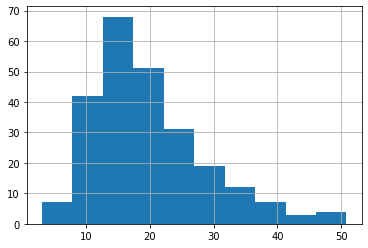

```python
tips.total_bill.hist()
```

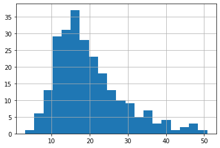

```python
tips.total_bill.hist(bins = 20)
```

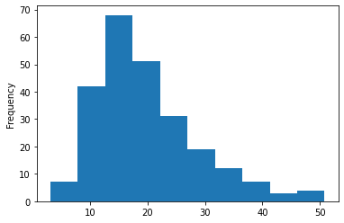

```python
tips.total_bill.plot(kind = "hist")
```

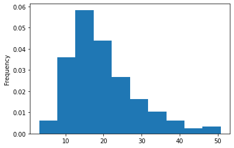

```python
tips.total_bill.plot(kind = "hist", density = True)
```

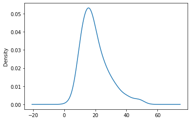

```python
tips.total_bill.plot(kind = "kde")
```

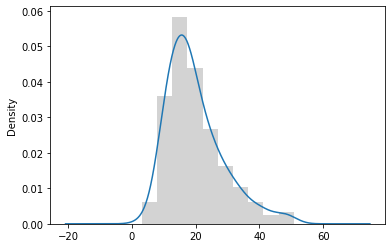

```python
# A mettre ensemble pour avoir densité + histogramme sur le même graphique
tips.total_bill.plot(kind = "hist", density = True, color = "lightgrey")
tips.total_bill.plot(kind = "kde")
```

- `seaborn`: Fonction `hisplot()`

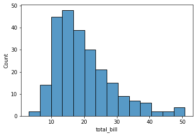

```python
seaborn.histplot(tips.total_bill)
```

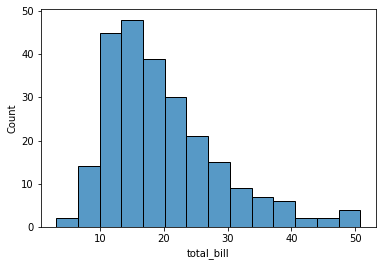

```python
seaborn.histplot(data = tips, x = "total_bill")
```

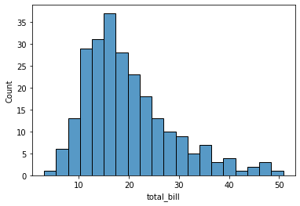

```python
seaborn.histplot(data = tips, x = "total_bill", bins = 20)
```

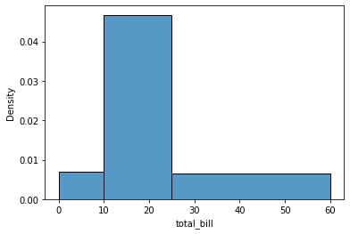

```python
seaborn.histplot(data = tips, x = "total_bill", bins = [0, 10, 25, 60], stat = "density")
```

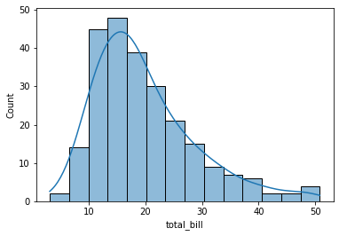

```python
seaborn.histplot(data = tips, x = "total_bill", kde = True)
```

#### Boîtes à moustaches

- `pandas` : Fonction `boxplot()`

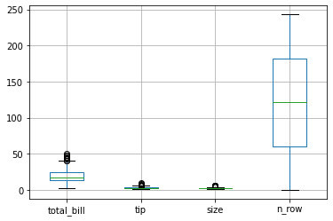

```python
tips.boxplot()
```

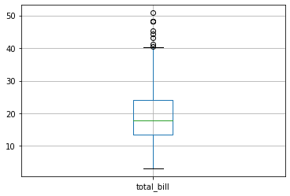

```python
tips.boxplot(column = "total_bill")
```

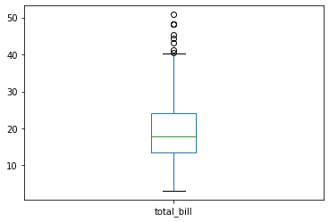

```python
tips.boxplot(column = "total_bill", grid = False)
```

- `seaborn` : Fonction `boxplot()`

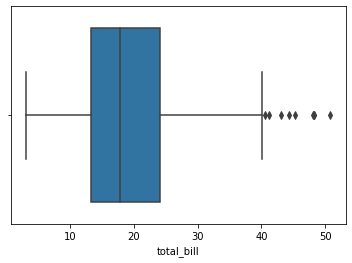

```python
seaborn.boxplot(x = "total_bill", data = tips)
```

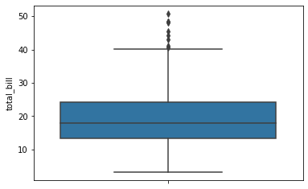

```python
seaborn.boxplot(y = "total_bill", data = tips)
```

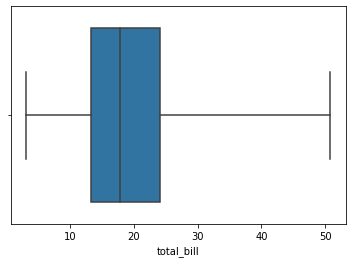

```python
seaborn.boxplot(x = "total_bill", data = tips, whis = 3)
```

- Autres représentations via `seaborn`

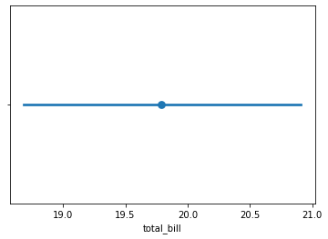

```python
seaborn.pointplot(x = "total_bill", data = tips)
```

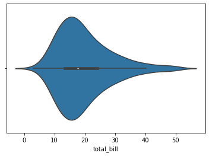

```python
seaborn.violinplot(x = "total_bill", data = tips)
```

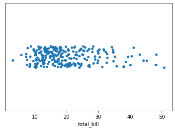

```python
seaborn.stripplot(x = "total_bill", data = tips, jitter = True)
```

### Qualitative

- Plusieurs façons
  - Table d'occurences (ou des effectifs)
  - Table des proportions

```python
tips.sex.describe()
```

```
count      244
unique       2
top       Male
freq       157
Name: sex, dtype: object
```

```python
tips.sex.unique()
```

```
array(['Female', 'Male'], dtype=object)
```

```python
tips.sex.value_counts()
```

```
Male      157
Female     87
Name: sex, dtype: int64
```

```python
pandas.crosstab(tips.sex, "freq")
```

| col_0 sex | freq |
| --- | --- |
| Female | 87 |
| Male | 157 |

```python
pandas.crosstab(tips.sex, "freq", normalize = True) # Proportion
```

| col_0 sex | freq |
| --- | --- |
| Female | 0.356557 |
| Male | 0.643443 |

- Test d'équi-probabilité

```python
t = pandas.crosstab(tips.sex, "freq", normalize=True)
scipy.stats.chisquare(t.freq)
```

```
Power_divergenceResult(statistic=0.08230314431604406, pvalue=0.774200187925369)
```

- Test de comparaison à une distribution connue

```python
scipy.stats.chisquare(t.freq, (.2, .8))
```

```
Power_divergenceResult(statistic=0.1531888269282451, pvalue=0.6955064385613343)
```

#### Diagramme en barres

- `pandas` : Fonction `bar()` ou type `"bar"` pour `plot()`
  - Calculs de proportions préférables parfois

```python
t = pandas.crosstab(tips.sex, "freq")
```

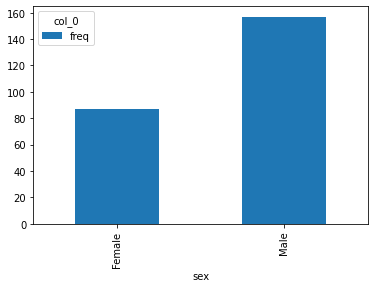

```python
t.plot.bar()
```

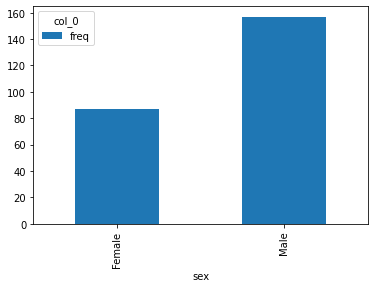

```python
t.plot(kind = "bar")
```

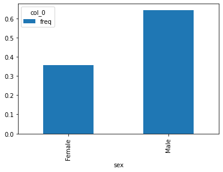

```python
# En proportion
t = pandas.crosstab(tips.sex, "freq", normalize=True)
t.plot(kind = "bar")
```

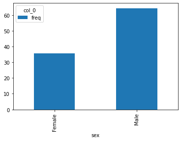

```python
# En pourcentage
(t * 100).plot(kind = "bar")
```

- `seaborn` : Fonctions `countplot()` ou `barplot()`

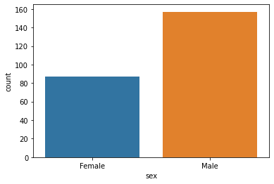

```python
seaborn.countplot(x = "sex", data = tips)
```

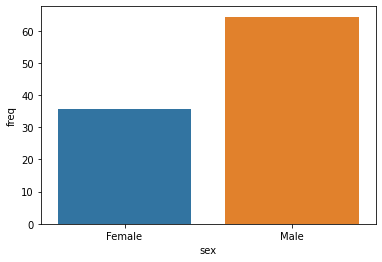

```python
# En pourcentage
t = pandas.crosstab(tips.sex, "freq", normalize=True)
t = t.assign(sex = t.index, freq = 100 * t.freq)
seaborn.barplot(x = "sex", y = "freq", data = t)
```

#### Diagramme circulaire

- `pandas` : Fonction `plot.pie()`

```
array([<AxesSubplot:ylabel='freq'>], dtype=object)
```

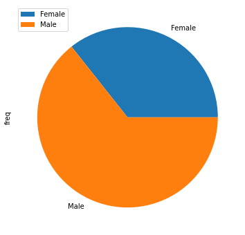

```python
t = pandas.crosstab(tips.sex, "freq")
t.plot.pie(subplots = True, figsize = (6, 6))
```

- Pas en `seaborn`

### Quantitative - quantitative

```python
tips.corr()
```

|  | total_bill | tip | size | n_row |
| --- | --- | --- | --- | --- |
| total_bill | 1.000000 | 0.675734 | 0.598315 | 0.044526 |
| tip | 0.675734 | 1.000000 | 0.489299 | -0.026709 |
| size | 0.598315 | 0.489299 | 1.000000 | 0.008061 |
| n_row | 0.044526 | -0.026709 | 0.008061 | 1.000000 |

```python
tips.total_bill.cov(tips.tip)
```

```
8.323501629224854
```

```python
tips.total_bill.corr(tips.tip)
```

```
0.6757341092113641
```

- Test de corrélation : Pearson

```python
scipy.stats.pearsonr(tips.total_bill, tips.tip)
```

```
(0.6757341092113647, 6.6924706468630016e-34)
```

- Test de corrélation : Kendall

```python
scipy.stats.kendalltau(tips.total_bill, tips.tip)
```

```
KendalltauResult(correlation=0.517180972142381, pvalue=2.4455728480214792e-32)
```